# Data Overview: School Attainment Analysis

# 3 Variable Definitions

Table 2 lists all variables used in the multilevel model, together with their role and a brief description. This serves as a reference for the sections that follow.

```r
model_vars_def <- c(
  "ATT8SCR", "ATT8SCR_FSM6CLA1A", "ATT8SCR_NFSM6CLA1A",
  "PTFSM6CLA1A", "PERCTOT", "PNUMEAL", "KS2ASS", "PTPRIORLO",
  "ADMPOL_PT", "gorard_segregation",
  "OFSTEDRATING_1", "gor_name", "LANAME",
  "remained_in_the_same_school",
  "teachers_on_leadership_pay_range_percent",
  "average_number_of_days_taken",
  "has_imputed_predictors"
)

tibble(
  Variable = model_vars_def,
  Label = var_labels(model_vars_def),
  Role = c(rep("Outcome", 3),
           rep("Fixed effect", 7),
           rep("Random intercept", 3),
           rep("Fixed effect", 3),
           "Flag")
) %>%
  kable(align = "lll") %>%
  kable_styling(bootstrap_options = c("striped", "hover", "condensed"),
                full_width = FALSE, font_size = 11) %>%
  pack_rows("Outcomes", 1, 3) %>%
  pack_rows("Fixed-effect predictors", 4, 10) %>%
  pack_rows("Random-effect grouping", 11, 13) %>%
  pack_rows("Workforce predictors", 14, 16) %>%
  pack_rows("Metadata", 17, 17) %>%
  save_tbl("variable_definitions")
```

Table 2: Definitions of all variables used in the multilevel model

| Variable | Label | Role |
| --- | --- | --- |
| **Outcomes** |  |  |
| ATT8SCR | Avg. Attainment 8 score per pupil | Outcome |
| ATT8SCR_FSM6CLA1A | Avg. Attainment 8 score (disadvantaged) | Outcome |
| ATT8SCR_NFSM6CLA1A | Avg. Attainment 8 score (non-disadvantaged) | Outcome |
| **Fixed-effect predictors** |  |  |
| PTFSM6CLA1A | % KS4 pupils who are disadvantaged | Fixed effect |
| PERCTOT | % overall absence | Fixed effect |
| PNUMEAL | % pupils with English not first language | Fixed effect |
| KS2ASS | KS2ASS | Fixed effect |
| PTPRIORLO | % KS4 pupils with low prior attainment (KS2) | Fixed effect |
| ADMPOL_PT | Admissions policy (new definition from 2019) | Fixed effect |
| gorard_segregation | Gorard segregation index | Fixed effect |
| **Random-effect grouping** |  |  |
| OFSTEDRATING_1 | Ofsted rating (harmonised) | Random intercept |
| gor_name | Government Office Region | Random intercept |
| LANAME | Local authority name | Random intercept |
| **Workforce predictors** |  |  |
| remained_in_the_same_school | Teachers remaining in same school (FTE) | Fixed effect |
| teachers_on_leadership_pay_range_percent | % teachers on leadership pay range | Fixed effect |
| average_number_of_days_taken | Avg. teacher sickness days | Fixed effect |
| **Metadata** |  |  |
| has_imputed_predictors | 2024-25 predictors are estimates (carry-forward) | Flag |

# 4 Panel Construction Pipeline

The panel is assembled through four sequential scripts, each adding data and producing an intermediate `.rds` file.

```r
tibble::tribble(
  ~Step, ~Script, ~`Input`, ~`Output`, ~Description,
  "1", "01_extract_data.R",
    "Raw DfE ZIPs", "year_data_list.rds",
    "Unzip, read KS4 + census + absence + school info per year; join by URN; filter RECTYPE=1 (mainstream)",
  "2", "02_build_panel.R",
    "year_data_list.rds", "panel_raw.rds",
    "Download Edubase (region/coords), Ofsted ratings, absence API; join to each year; harmonise Ofsted text/numeric; stack into panel",
  "3", "03_add_workforce.R",
    "panel_raw.rds", "panel_with_workforce.rds",
    "Download 5 workforce datasets from EES (turnover, pay, sickness, size, ratios); join by URN + time_period",
  "4", "04_compute_derived.R",
    "panel_with_workforce.rds", "panel_data.rds",
    "Gorard segregation index; impute 2024-25 missing predictors; log transforms; final cleaning"
) %>%
  kable(align = "clllll") %>%
  kable_styling(bootstrap_options = c("striped", "hover", "condensed"),
                full_width = FALSE, font_size = 10) %>%
  column_spec(5, width = "25em") %>%
  save_tbl("pipeline_steps")
```

Table 3: Data pipeline steps from raw ZIP files to the final analysis panel

| Step | Script | Input | Output | Description |
| --- | --- | --- | --- | --- |
| 1 | 01_extract_data.R | Raw DfE ZIPs | year_data_list.rds | Unzip, read KS4 + census + absence + school info per year; join by URN; filter RECTYPE=1 (mainstream) |
| 2 | 02_build_panel.R | year_data_list.rds | panel_raw.rds | Download Edubase (region/coords), Ofsted ratings, absence API; join to each year; harmonise Ofsted text/numeric; stack into panel |
| 3 | 03_add_workforce.R | panel_raw.rds | panel_with_workforce.rds | Download 5 workforce datasets from EES (turnover, pay, sickness, size, ratios); join by URN + time_period |
| 4 | 04_compute_derived.R | panel_with_workforce.rds | panel_data.rds | Gorard segregation index; impute 2024-25 missing predictors; log transforms; final cleaning |

# 5 Sample Overview

## 5.1 Panel Dimensions

```r
sample_tbl <- model_panel %>%
  group_by(`Academic year` = year_label) %>%
  summarise(
    Schools = n_distinct(URN),
    `School-year obs.` = n(),
    LAs = n_distinct(LANAME),
    Regions = n_distinct(gor_name),
    .groups = "drop"
  )

totals <- tibble(
  `Academic year` = "Total / Overall",
  Schools = n_distinct(model_panel$URN),
  `School-year obs.` = nrow(model_panel),
  LAs = n_distinct(model_panel$LANAME),
  Regions = n_distinct(model_panel$gor_name)
)

bind_rows(sample_tbl, totals) %>%
  kable(align = "lrrrr", format.args = list(big.mark = ",")) %>%
  kable_styling(bootstrap_options = c("striped", "hover", "condensed"),
                full_width = FALSE) %>%
  row_spec(nrow(sample_tbl) + 1, bold = TRUE) %>%
  save_tbl("panel_dimensions")
```

Table 4: Panel dimensions by academic year (state-funded mainstream schools only)

| Academic year | Schools | School-year obs. | LAs | Regions |
| --- | --- | --- | --- | --- |
| 2021-22 | 3,349 | 3,349 | 152 | 9 |
| 2022-23 | 3,351 | 3,351 | 152 | 9 |
| 2023-24 | 3,372 | 3,372 | 152 | 9 |
| 2024-25 | 3,347 | 3,347 | 152 | 9 |
| Total / Overall | 3,523 | 13,419 | 152 | 9 |

**ImportantSample restriction**

All figures and tables in this report are based on the **analysis sample** of mainstream state-funded schools only (Academies and LA-maintained schools). The following school types have been excluded from the raw extract:

Table 5

| School type | Observations | Schools |
| --- | --- | --- |
| Independent school | 3,641 | 987 |
| College | 55 | 17 |
| Special school | 15 | 15 |
| Total excluded | 3,711 | NA |

This reduces the panel from 17,130 to **13,419** school-year observations (3,523 unique schools across 152 LAs). These school types are excluded because they operate under different funding, governance, and accountability frameworks that make direct comparison with the mainstream state-funded sector inappropriate. Independent schools, in particular, do not participate in the same performance table reporting regime, and their inclusion would confound the relationship between deprivation-related predictors and attainment outcomes.

## 5.2 Geographic Distribution

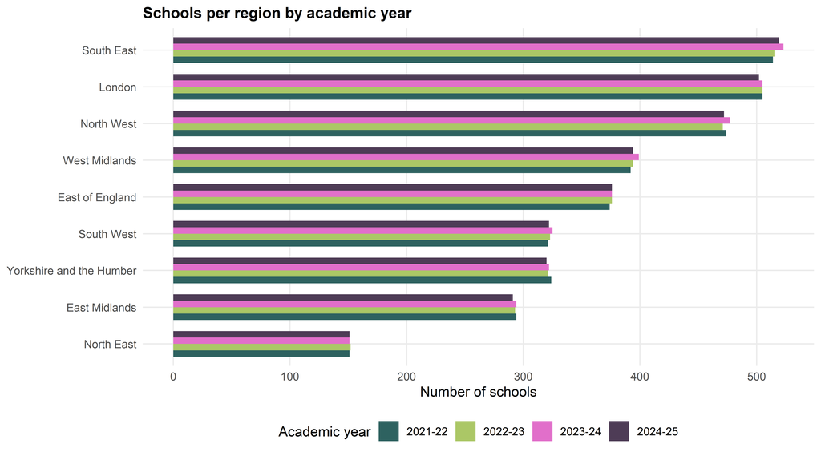

Figure 1: Number of schools per region and academic year

```r
p_region <- model_panel %>%
  filter(!is.na(gor_name)) %>%
  count(gor_name, year_label) %>%
  ggplot(aes(x = fct_reorder(gor_name, n, .fun = sum), y = n, fill = year_label)) +
  geom_col(position = "dodge", width = 0.7) +
  coord_flip() +
  scale_fill_manual(values = year_cols, name = "Academic year") +
  labs(x = NULL, y = "Number of schools",
       title = "Schools per region by academic year") +
  theme_pub

save_fig(p_region, "region_counts", width = 8, height = 5)
p_region
```

The South East, North West, and London contribute the largest number of schools, consistent with their population sizes. School counts are highly stable across years, reflecting the fact that the panel tracks the same institutions over time with minimal entry or exit.

## 5.3 School Type Composition

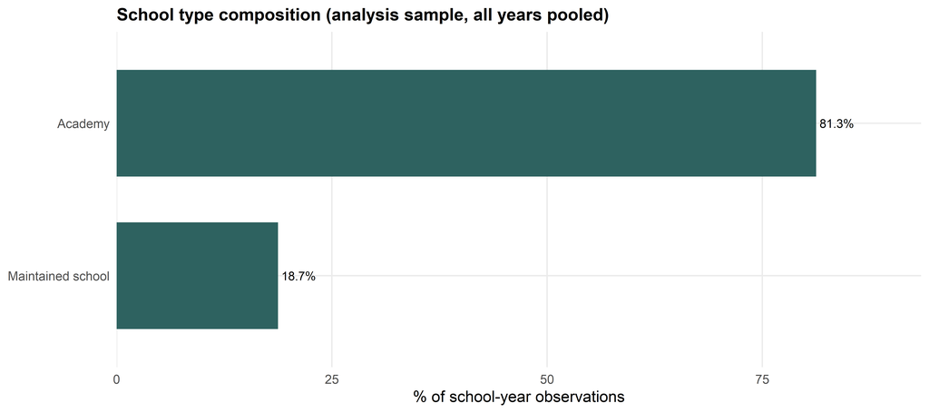

Figure 2: School type composition across the panel

```r
p_types <- model_panel %>%
  filter(!is.na(MINORGROUP)) %>%
  count(MINORGROUP) %>%
  mutate(pct = n / sum(n) * 100,
         MINORGROUP = fct_reorder(MINORGROUP, n)) %>%
  ggplot(aes(x = MINORGROUP, y = pct)) +
  geom_col(fill = "#2e6260", width = 0.7) +
  geom_text(aes(label = sprintf("%.1f%%", pct)), hjust = -0.1, size = 3) +
  coord_flip() +
  labs(x = NULL, y = "% of school-year observations",
       title = "School type composition (analysis sample, all years pooled)") +
  scale_y_continuous(expand = expansion(mult = c(0, 0.15))) +
  theme_pub

save_fig(p_types, "school_types", width = 7, height = 4)
p_types
```

Academies form the largest group in the analysis sample, followed by Maintained schools. Independent schools, colleges, and special schools have been excluded from all figures and tables in this report (see Table 10 for the full breakdown).

## 5.4 Ofsted Rating Distribution

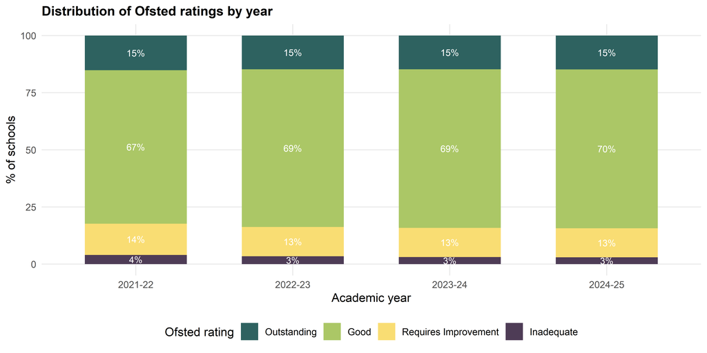

Figure 3: Ofsted rating distribution by academic year

```r
p_ofsted <- model_panel %>%
  filter(!is.na(OFSTEDRATING_1)) %>%
  count(year_label, OFSTEDRATING_1) %>%
  group_by(year_label) %>%
  mutate(pct = n / sum(n) * 100) %>%
  ungroup() %>%
  ggplot(aes(x = year_label, y = pct, fill = OFSTEDRATING_1)) +
  geom_col(position = "stack", width = 0.65) +
  geom_text(aes(label = sprintf("%.0f%%", pct)),
            position = position_stack(vjust = 0.5), size = 3, colour = "white") +
  scale_fill_manual(
    values = c("Outstanding" = "#2e6260", "Good" = "#abc766",
               "Requires Improvement" = "#f9dd73", "Inadequate" = "#4e3c56"),
    name = "Ofsted rating"
  ) +
  labs(x = "Academic year", y = "% of schools",
       title = "Distribution of Ofsted ratings by year") +
  theme_pub

save_fig(p_ofsted, "ofsted_distribution", width = 7, height = 4.5)
p_ofsted
```

The vast majority of schools in the analysis sample are rated Good, followed by Outstanding. The proportion rated Requires Improvement or Inadequate is small and relatively stable across years. Because Ofsted ratings are carried forward until a school is re-inspected, the year-to-year changes are modest and reflect the pace of the inspection cycle rather than rapid shifts in school quality.

## 5.5 Admissions Policy

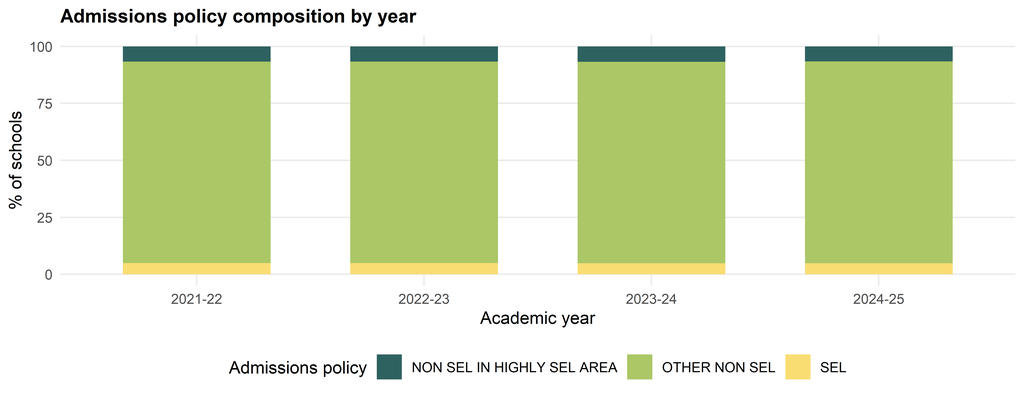

Figure 4: Admissions policy distribution

```r
if ("ADMPOL_PT" %in% names(model_panel)) {
  p_adm <- model_panel %>%
    filter(!is.na(ADMPOL_PT)) %>%
    mutate(ADMPOL_PT = factor(ADMPOL_PT)) %>%
    count(year_label, ADMPOL_PT) %>%
    group_by(year_label) %>%
    mutate(pct = n / sum(n) * 100) %>%
    ggplot(aes(x = year_label, y = pct, fill = ADMPOL_PT)) +
    geom_col(position = "stack", width = 0.65) +
    scale_fill_manual(values = c("#2e6260", "#abc766", "#f9dd73", "#e16fca", "#4e3c56", "#49a0c4", "#ff7f89"), name = "Admissions policy") +
    labs(x = "Academic year", y = "% of schools",
         title = "Admissions policy composition by year") +
    theme_pub

  save_fig(p_adm, "admissions_policy", width = 7, height = 3.5)
  p_adm
}
```

The admissions policy variable captures whether a school selects pupils on academic ability. The overwhelming majority of mainstream state-funded schools operate non-selective admissions; the small selective share is concentrated in areas that retain grammar schools. This variable is included in the model to control for the compositional advantage that selective schools enjoy.

# 6 Outcome Variables

**NoteAnalysis sample**

From this section onward, all statistics, figures, and tables are based on the **analysis sample** of mainstream state-funded schools only — Academies and Maintained schools. Independent schools (3,641 observations), colleges (55), and special schools (15) are excluded because they operate under different funding, governance, and accountability frameworks that make direct comparison with the mainstream sector inappropriate. This reduces the panel from 17,130 to **13,419** school-year observations. Full details of the restriction are given in Table 10.

## 6.1 Descriptive Statistics

```r
outcome_vars <- c("ATT8SCR", "ATT8SCR_FSM6CLA1A", "ATT8SCR_NFSM6CLA1A")

outcome_stats <- model_panel %>%
  pivot_longer(all_of(outcome_vars), names_to = "Variable", values_to = "value") %>%
  filter(!is.na(value)) %>%
  group_by(Variable, `Year` = year_label) %>%
  summarise(
    N     = n(),
    Mean  = round(mean(value), 1),
    SD    = round(sd(value), 1),
    Min   = round(min(value), 1),
    Median = round(median(value), 1),
    Max   = round(max(value), 1),
    .groups = "drop"
  ) %>%
  mutate(Variable = var_label(Variable))

outcome_stats %>%
  kable(align = "llrrrrrr") %>%
  kable_styling(bootstrap_options = c("striped", "hover", "condensed"),
                full_width = FALSE, font_size = 11) %>%
  collapse_rows(columns = 1, valign = "top") %>%
  save_tbl("outcome_statistics")
```

Table 6: Descriptive statistics for Attainment 8 outcome variables by academic year

| Variable | Year | N | Mean | SD | Min | Median | Max |
| --- | --- | --- | --- | --- | --- | --- | --- |
| Avg. Attainment 8 score per pupil | 2021-22 | 3228 | 49.3 | 9.3 | 9.0 | 48.4 | 88.2 |
|  | 2022-23 | 3250 | 46.9 | 9.3 | 12.0 | 45.8 | 87.6 |
|  | 2023-24 | 3270 | 46.7 | 9.5 | 0.8 | 45.7 | 86.6 |
|  | 2024-25 | 3277 | 46.8 | 9.3 | 0.9 | 45.6 | 87.2 |
| Avg. Attainment 8 score (disadvantaged) | 2021-22 | 3184 | 40.4 | 9.2 | 12.9 | 38.8 | 85.1 |
|  | 2022-23 | 3204 | 37.7 | 9.2 | 10.9 | 36.0 | 85.8 |
|  | 2023-24 | 3232 | 37.5 | 9.6 | 14.3 | 36.0 | 85.9 |
|  | 2024-25 | 3246 | 37.7 | 9.4 | 18.1 | 36.0 | 86.0 |
| Avg. Attainment 8 score (non-disadvantaged) | 2021-22 | 3186 | 52.0 | 8.3 | 11.2 | 51.4 | 86.5 |
|  | 2022-23 | 3206 | 49.6 | 8.2 | 12.8 | 48.8 | 86.4 |
|  | 2023-24 | 3235 | 49.5 | 8.3 | 14.8 | 48.6 | 86.7 |
|  | 2024-25 | 3247 | 49.9 | 8.3 | 25.9 | 48.7 | 87.5 |

```r
outcome_stats_pooled <- model_panel %>%
  pivot_longer(all_of(outcome_vars), names_to = "Variable", values_to = "value") %>%
  filter(!is.na(value)) %>%
  group_by(Variable) %>%
  summarise(
    N      = n(),
    Mean   = round(mean(value), 1),
    SD     = round(sd(value), 1),
    Min    = round(min(value), 1),
    Median = round(median(value), 1),
    Max    = round(max(value), 1),
    .groups = "drop"
  ) %>%
  mutate(Variable = var_label(Variable))

outcome_stats_pooled %>%
  kable(align = "lrrrrrr") %>%
  kable_styling(bootstrap_options = c("striped", "hover", "condensed"),
                full_width = FALSE, font_size = 11) %>%
  save_tbl("outcome_statistics_pooled")
```

Table 7: Descriptive statistics for Attainment 8 outcome variables (full panel, pooled across years)

| Variable | N | Mean | SD | Min | Median | Max |
| --- | --- | --- | --- | --- | --- | --- |
| Avg. Attainment 8 score per pupil | 13025 | 47.4 | 9.4 | 0.8 | 46.3 | 88.2 |
| Avg. Attainment 8 score (disadvantaged) | 12866 | 38.3 | 9.4 | 10.9 | 36.8 | 86.0 |
| Avg. Attainment 8 score (non-disadvantaged) | 12874 | 50.2 | 8.3 | 11.2 | 49.3 | 87.5 |

## 6.2 Outcome Distributions

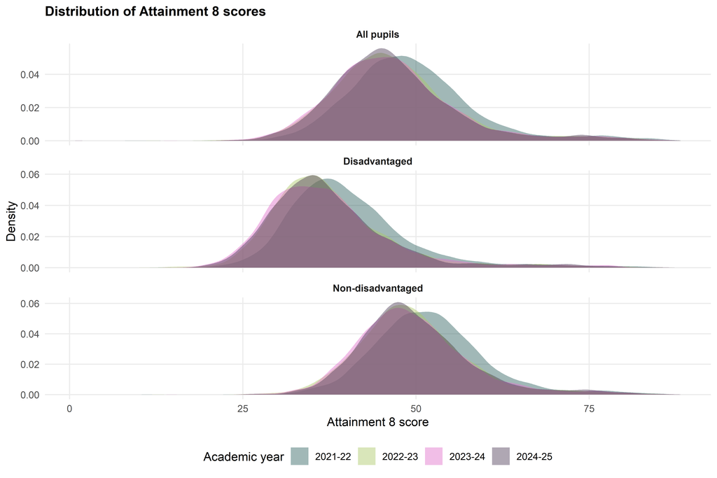

Figure 5: Density plots of Attainment 8 scores by pupil group and year

```r
outcome_long <- model_panel %>%
  select(year_label, all_of(outcome_vars)) %>%
  pivot_longer(-year_label, names_to = "outcome", values_to = "score") %>%
  filter(!is.na(score)) %>%
  mutate(
    outcome = recode(outcome,
      ATT8SCR               = "All pupils",
      ATT8SCR_FSM6CLA1A     = "Disadvantaged",
      ATT8SCR_NFSM6CLA1A    = "Non-disadvantaged"
    ),
    outcome = factor(outcome,
                     levels = c("All pupils", "Disadvantaged", "Non-disadvantaged"))
  )

p_density <- ggplot(outcome_long, aes(x = score, fill = year_label)) +
  geom_density(alpha = 0.45, colour = NA) +
  facet_wrap(~ outcome, ncol = 1, scales = "free_y") +
  scale_fill_manual(values = year_cols, name = "Academic year") +
  labs(x = "Attainment 8 score", y = "Density",
       title = "Distribution of Attainment 8 scores") +
  theme_pub

save_fig(p_density, "outcome_density", width = 8, height = 7)
p_density
```

The density plots confirm that all three Attainment 8 measures are unimodal and broadly symmetric. The disadvantaged subgroup distribution is shifted noticeably to the left, with a slight positive tail. Year-on-year shapes are stable (especially since 2022-23 - post COVID), suggesting that the national distribution of school-level attainment has not shifted dramatically over the period, except for an immediately post-COVID drop.

## 6.3 Disadvantage Gap Over Time

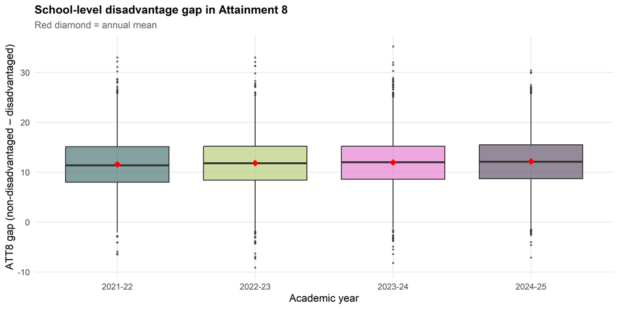

Figure 6: Attainment gap between non-disadvantaged and disadvantaged pupils by year

```r
gap_data <- model_panel %>%
  filter(!is.na(ATT8SCR_FSM6CLA1A), !is.na(ATT8SCR_NFSM6CLA1A)) %>%
  mutate(gap = ATT8SCR_NFSM6CLA1A - ATT8SCR_FSM6CLA1A)

gap_summary <- gap_data %>%
  group_by(year_label) %>%
  summarise(
    mean_gap   = mean(gap, na.rm = TRUE),
    median_gap = median(gap, na.rm = TRUE),
    sd_gap     = sd(gap, na.rm = TRUE),
    n = n(),
    .groups = "drop"
  )

p_gap <- ggplot(gap_data, aes(x = year_label, y = gap)) +
  geom_boxplot(aes(fill = year_label), alpha = 0.6, outlier.size = 0.5,
               show.legend = FALSE) +
  geom_point(data = gap_summary, aes(y = mean_gap),
             shape = 18, size = 3, colour = "red") +
  scale_fill_manual(values = year_cols) +
  labs(x = "Academic year",
       y = "ATT8 gap (non-disadvantaged \u2013 disadvantaged)",
       title = "School-level disadvantage gap in Attainment 8",
       subtitle = "Red diamond = annual mean") +
  theme_pub

save_fig(p_gap, "disadvantage_gap_trend", width = 7, height = 4.5)
p_gap
```

## 6.4 Outcomes by Region

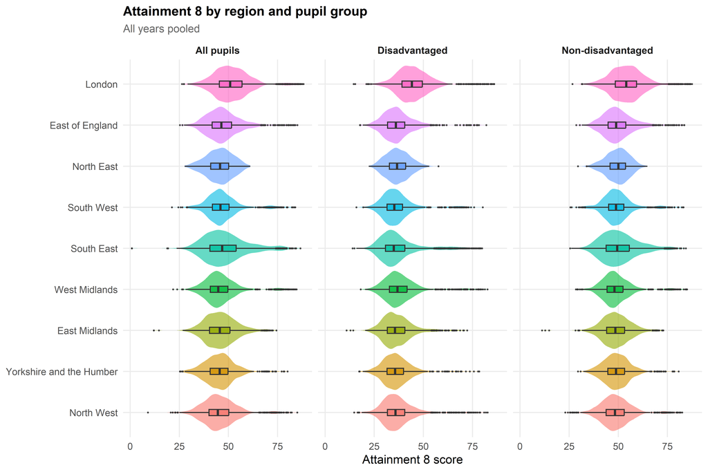

Figure 7: Attainment 8 distributions by region — the grouping variable for the multilevel model’s regional random intercept

```r
p_outcome_region <- model_panel %>%
  filter(!is.na(gor_name)) %>%
  select(gor_name, all_of(outcome_vars)) %>%
  pivot_longer(-gor_name, names_to = "outcome", values_to = "score") %>%
  filter(!is.na(score)) %>%
  mutate(
    outcome = recode(outcome,
      ATT8SCR            = "All pupils",
      ATT8SCR_FSM6CLA1A  = "Disadvantaged",
      ATT8SCR_NFSM6CLA1A = "Non-disadvantaged"
    ),
    outcome = factor(outcome,
                     levels = c("All pupils", "Disadvantaged", "Non-disadvantaged")),
    gor_name = fct_reorder(gor_name, score, .fun = median)
  )

p_out_reg <- ggplot(p_outcome_region, aes(x = gor_name, y = score, fill = gor_name)) +
  geom_violin(alpha = 0.6, colour = NA, scale = "width") +
  geom_boxplot(width = 0.15, alpha = 0.8, outlier.size = 0.3, show.legend = FALSE) +
  facet_wrap(~ outcome, ncol = 3) +
  coord_flip() +
  labs(x = NULL, y = "Attainment 8 score",
       title = "Attainment 8 by region and pupil group",
       subtitle = "All years pooled") +
  theme_pub +
  theme(legend.position = "none",
        strip.text = element_text(size = 9))

save_fig(p_out_reg, "outcome_by_region", width = 11, height = 6)
p_out_reg
```

## 6.5 Outcomes by Ofsted Rating

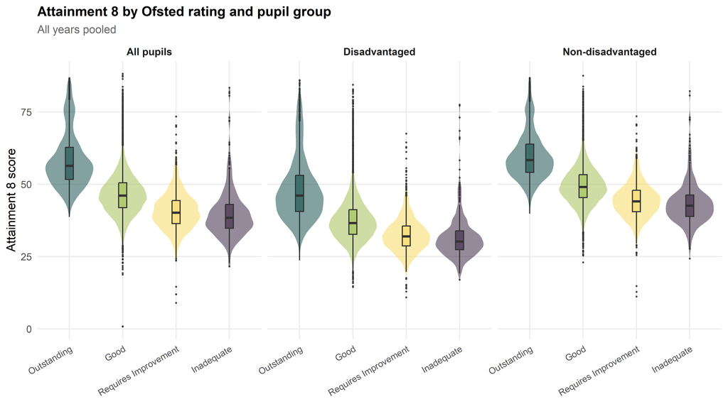

Figure 8: Attainment 8 distributions by Ofsted rating — the grouping variable for the multilevel model’s Ofsted random intercept

```r
p_outcome_ofsted <- model_panel %>%
  filter(!is.na(OFSTEDRATING_1)) %>%
  select(OFSTEDRATING_1, all_of(outcome_vars)) %>%
  pivot_longer(-OFSTEDRATING_1, names_to = "outcome", values_to = "score") %>%
  filter(!is.na(score)) %>%
  mutate(
    outcome = recode(outcome,
      ATT8SCR            = "All pupils",
      ATT8SCR_FSM6CLA1A  = "Disadvantaged",
      ATT8SCR_NFSM6CLA1A = "Non-disadvantaged"
    ),
    outcome = factor(outcome,
                     levels = c("All pupils", "Disadvantaged", "Non-disadvantaged"))
  )

ofsted_cols <- c("Outstanding" = "#2e6260", "Good" = "#abc766",
                 "Requires Improvement" = "#f9dd73", "Inadequate" = "#4e3c56")

p_out_ofs <- ggplot(p_outcome_ofsted,
                    aes(x = OFSTEDRATING_1, y = score, fill = OFSTEDRATING_1)) +
  geom_violin(alpha = 0.6, colour = NA, scale = "width") +
  geom_boxplot(width = 0.15, alpha = 0.8, outlier.size = 0.3, show.legend = FALSE) +
  facet_wrap(~ outcome, ncol = 3) +
  scale_fill_manual(values = ofsted_cols) +
  labs(x = NULL, y = "Attainment 8 score",
       title = "Attainment 8 by Ofsted rating and pupil group",
       subtitle = "All years pooled") +
  theme_pub +
  theme(legend.position = "none",
        axis.text.x = element_text(angle = 30, hjust = 1, size = 8),
        strip.text = element_text(size = 9))

save_fig(p_out_ofs, "outcome_by_ofsted", width = 10, height = 5)
p_out_ofs
```

**TipRelation to the multilevel null model**

These two plots illustrate the structure captured by the **random intercepts** in the multilevel model. Region (`gor_name`) and Ofsted rating (`OFSTEDRATING_1`) each enter as grouping variables, allowing the model to estimate a separate baseline (intercept) for each level. Before any school-level predictors are added, these group-level intercepts absorb the systematic variation visible in the violin plots above — effectively representing a **null model** that accounts only for which region and Ofsted category a school belongs to. The fixed-effect predictors (deprivation, absence, EAL, etc.) then explain the remaining within-group variation around these baselines.

# 7 Predictor Variables

## 7.1 Descriptive Statistics

```r
pred_vars_yr <- c(
  "PTFSM6CLA1A", "PERCTOT", "PNUMEAL", "KS2ASS", "PTPRIORLO",
  "gorard_segregation",
  "remained_in_the_same_school",
  "teachers_on_leadership_pay_range_percent",
  "average_number_of_days_taken"
)
pred_vars_yr <- intersect(pred_vars_yr, names(model_panel))

pred_table_yearly <- model_panel %>%
  pivot_longer(all_of(pred_vars_yr), names_to = "Variable", values_to = "value") %>%
  filter(!is.na(value)) %>%
  group_by(Variable, Year = year_label) %>%
  summarise(
    N      = n(),
    Mean   = round(mean(value), 2),
    SD     = round(sd(value), 2),
    Min    = round(min(value), 2),
    Median = round(median(value), 2),
    Max    = round(max(value), 2),
    .groups = "drop"
  ) %>%
  mutate(Variable = var_label(Variable))

pred_table_yearly %>%
  kable(align = "llrrrrrr") %>%
  kable_styling(bootstrap_options = c("striped", "hover", "condensed"),
                full_width = FALSE, font_size = 11) %>%
  collapse_rows(columns = 1, valign = "top") %>%
  save_tbl("predictor_statistics_yearly")
```

Table 8: Descriptive statistics for predictor variables by academic year

| Variable | Year | N | Mean | SD | Min | Median | Max |
| --- | --- | --- | --- | --- | --- | --- | --- |
| KS2ASS | 2021-22 | 3228 | 103.75 | 2.96 | 93.10 | 103.50 | 117.40 |
|  | 2022-23 | 3250 | 104.36 | 2.73 | 91.70 | 104.10 | 117.40 |
|  | 2023-24 | 3270 | 104.45 | 2.70 | 94.50 | 104.20 | 117.00 |
| % overall absence | 2021-22 | 3309 | 9.14 | 2.40 | 2.10 | 9.00 | 28.10 |
|  | 2022-23 | 3316 | 9.19 | 2.62 | 3.10 | 8.90 | 32.60 |
|  | 2023-24 | 3332 | 9.08 | 2.63 | 2.60 | 8.80 | 26.90 |
|  | 2024-25 | 3322 | 8.25 | 2.45 | 1.98 | 8.05 | 26.73 |
| % pupils with English not first language | 2021-22 | 3303 | 17.29 | 18.83 | 0.00 | 9.30 | 93.30 |
|  | 2022-23 | 3308 | 17.96 | 18.46 | 0.00 | 10.45 | 92.70 |
|  | 2023-24 | 3318 | 18.43 | 18.20 | 0.00 | 11.40 | 94.80 |
|  | 2024-25 | 3284 | 18.48 | 18.24 | 0.00 | 11.40 | 94.80 |
| % KS4 pupils who are disadvantaged | 2021-22 | 3228 | 26.88 | 14.87 | 0.00 | 24.00 | 96.00 |
|  | 2022-23 | 3250 | 26.70 | 14.39 | 0.00 | 24.00 | 93.00 |
|  | 2023-24 | 3270 | 26.65 | 13.99 | 0.00 | 24.40 | 82.80 |
|  | 2024-25 | 3277 | 28.35 | 14.46 | 0.00 | 25.90 | 80.10 |
| % KS4 pupils with low prior attainment (KS2) | 2021-22 | 3228 | 25.78 | 11.20 | 0.00 | 26.00 | 74.00 |
|  | 2022-23 | 3250 | 22.24 | 9.99 | 0.00 | 22.00 | 92.00 |
|  | 2023-24 | 3270 | 22.13 | 9.65 | 0.00 | 22.00 | 79.20 |
| Avg. teacher sickness days | 2021-22 | 3098 | 8.66 | 3.88 | 0.00 | 8.50 | 85.00 |
|  | 2022-23 | 3018 | 7.83 | 3.58 | 0.00 | 7.30 | 91.50 |
|  | 2023-24 | 3248 | 8.07 | 3.54 | 0.00 | 7.60 | 74.00 |
| Gorard segregation index | 2021-22 | 3226 | 0.18 | 0.05 | 0.00 | 0.17 | 0.31 |
|  | 2022-23 | 3248 | 0.17 | 0.05 | 0.00 | 0.17 | 0.32 |
|  | 2023-24 | 3267 | 0.17 | 0.05 | 0.00 | 0.16 | 0.30 |
|  | 2024-25 | 3276 | 0.16 | 0.04 | 0.00 | 0.15 | 0.27 |
| Teachers remaining in same school (FTE) | 2021-22 | 3302 | 52.71 | 21.77 | 0.00 | 51.40 | 146.50 |
|  | 2022-23 | 3292 | 52.56 | 21.63 | 0.00 | 51.00 | 151.90 |
|  | 2023-24 | 3311 | 53.49 | 21.65 | 0.00 | 51.90 | 155.90 |
| % teachers on leadership pay range | 2021-22 | 3301 | 11.59 | 5.14 | 0.00 | 10.64 | 66.67 |
|  | 2022-23 | 3292 | 11.63 | 5.01 | 0.00 | 10.77 | 60.00 |
|  | 2023-24 | 3311 | 12.07 | 5.15 | 0.00 | 11.25 | 75.00 |
|  | 2024-25 | 3314 | 12.23 | 5.09 | 0.00 | 11.32 | 66.67 |

```r
pred_vars <- c(
  "PTFSM6CLA1A", "PERCTOT", "PNUMEAL", "KS2ASS", "PTPRIORLO",
  "gorard_segregation",
  "remained_in_the_same_school",
  "teachers_on_leadership_pay_range_percent",
  "average_number_of_days_taken"
)
pred_vars <- intersect(pred_vars, names(model_panel))

pred_table <- map_dfr(pred_vars, function(v) {
  x <- model_panel[[v]]
  tibble(
    Variable = var_label(v),
    N        = sum(!is.na(x)),
    `% available` = round(sum(!is.na(x)) / nrow(model_panel) * 100, 1),
    Mean     = round(mean(x, na.rm = TRUE), 2),
    SD       = round(sd(x, na.rm = TRUE), 2),
    Min      = round(min(x, na.rm = TRUE), 2),
    Median   = round(median(x, na.rm = TRUE), 2),
    Max      = round(max(x, na.rm = TRUE), 2)
  )
})

pred_table %>%
  kable(align = "lrrrrrrr") %>%
  kable_styling(bootstrap_options = c("striped", "hover", "condensed"),
                full_width = FALSE, font_size = 11) %>%
  pack_rows("School composition", 1, 4) %>%
  pack_rows("Segregation (LA-level)", 5, 5) %>%
  pack_rows("Workforce", 6, nrow(pred_table)) %>%
  save_tbl("predictor_statistics")
```

Table 9: Descriptive statistics for predictor variables (full panel, pooled across years)

| Variable | N | % available | Mean | SD | Min | Median | Max |
| --- | --- | --- | --- | --- | --- | --- | --- |
| **School composition** |  |  |  |  |  |  |  |
| % KS4 pupils who are disadvantaged | 13025 | 97.1 | 27.14 | 14.45 | 0.00 | 24.90 | 96.00 |
| % overall absence | 13279 | 99.0 | 8.91 | 2.56 | 1.98 | 8.70 | 32.60 |
| % pupils with English not first language | 13213 | 98.5 | 18.04 | 18.44 | 0.00 | 10.80 | 94.80 |
| KS2ASS | 9748 | 72.6 | 104.19 | 2.81 | 91.70 | 104.00 | 117.40 |
| **Segregation (LA-level)** |  |  |  |  |  |  |  |
| % KS4 pupils with low prior attainment (KS2) | 9748 | 72.6 | 23.38 | 10.43 | 0.00 | 23.00 | 92.00 |
| **Workforce** |  |  |  |  |  |  |  |
| Gorard segregation index | 13017 | 97.0 | 0.17 | 0.05 | 0.00 | 0.17 | 0.32 |
| Teachers remaining in same school (FTE) | 9905 | 73.8 | 52.92 | 21.68 | 0.00 | 51.40 | 155.90 |
| % teachers on leadership pay range | 13218 | 98.5 | 11.88 | 5.10 | 0.00 | 11.00 | 75.00 |
| Avg. teacher sickness days | 9364 | 69.8 | 8.19 | 3.68 | 0.00 | 7.70 | 91.50 |

## 7.2 Predictor Distributions

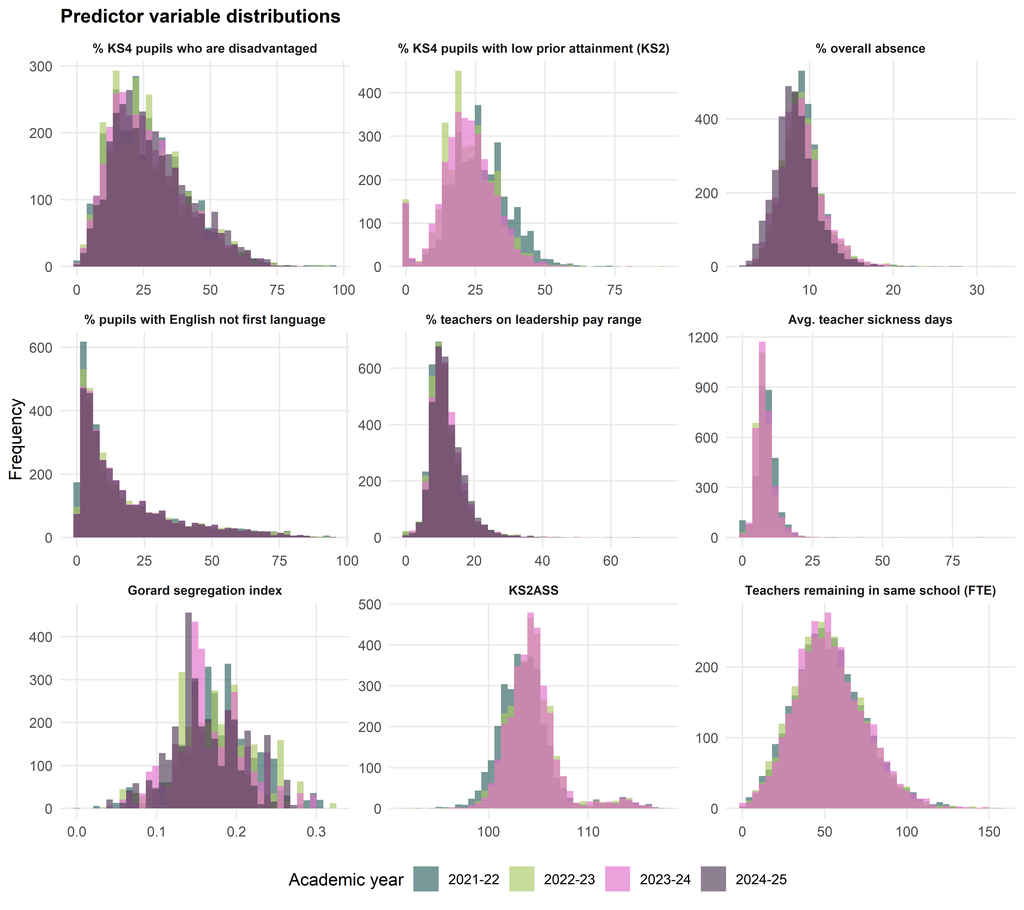

Figure 9: Distributions of key predictor variables (raw scale)

```r
pred_long <- model_panel %>%
  select(year_label, all_of(pred_vars)) %>%
  pivot_longer(-year_label, names_to = "variable", values_to = "value") %>%
  filter(!is.na(value)) %>%
  mutate(variable = var_label(variable))

p_hist <- ggplot(pred_long, aes(x = value)) +
  geom_histogram(aes(fill = year_label), bins = 40, alpha = 0.65,
                 position = "identity", colour = NA) +
  facet_wrap(~ variable, scales = "free", ncol = 3) +
  scale_fill_manual(values = year_cols, name = "Academic year") +
  labs(x = NULL, y = "Frequency",
       title = "Predictor variable distributions") +
  theme_pub +
  theme(strip.text = element_text(size = 8))

save_fig(p_hist, "predictor_distributions", width = 10, height = 8)
p_hist
```

Several predictors exhibit clear right skew — notably the proportion of pupils with English as an additional language (PNUMEAL) and average teacher sickness days. The FSM eligibility rate and overall absence rate are also right-skewed, though less severely. By contrast, the Gorard segregation index and teacher retention FTE are approximately symmetric. These distributional differences motivate the selective log-transformation strategy described below.

## 7.3 Log-Transformed Predictors

Predictors with |skewness| > 1 are log-transformed for the multilevel model. `remained_in_the_same_school` (skewness = 0.47) is entered on the raw scale as it is near-symmetric. Figure 10 shows the raw and log-transformed distributions for the variables that undergo this transformation.

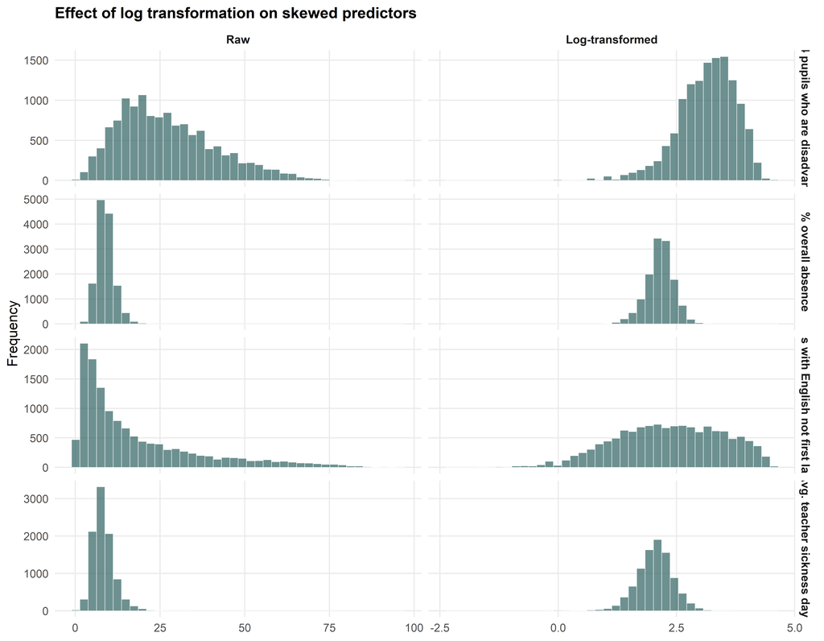

Figure 10: Raw vs. log-transformed distributions for skewed predictor variables

```r
log_vars <- c("PTFSM6CLA1A", "PERCTOT", "PNUMEAL",
              "average_number_of_days_taken")
log_vars <- intersect(log_vars, names(model_panel))

raw_long <- model_panel %>%
  select(all_of(log_vars)) %>%
  pivot_longer(everything(), names_to = "variable", values_to = "value") %>%
  filter(!is.na(value), value > 0) %>%
  mutate(scale = "Raw")

log_long <- model_panel %>%
  select(all_of(log_vars)) %>%
  mutate(across(everything(), safe_log)) %>%
  pivot_longer(everything(), names_to = "variable", values_to = "value") %>%
  filter(!is.na(value)) %>%
  mutate(scale = "Log-transformed")

compare_long <- bind_rows(raw_long, log_long) %>%
  mutate(
    variable = var_label(variable),
    scale = factor(scale, levels = c("Raw", "Log-transformed"))
  )

p_log <- ggplot(compare_long, aes(x = value)) +
  geom_histogram(bins = 40, fill = "#2e6260", alpha = 0.7, colour = "white",
                 linewidth = 0.2) +
  facet_grid(variable ~ scale, scales = "free") +
  labs(x = NULL, y = "Frequency",
       title = "Effect of log transformation on skewed predictors") +
  theme_pub +
  theme(strip.text = element_text(size = 9))

save_fig(p_log, "log_transform_comparison", width = 8, height = 7)
p_log
```

The side-by-side comparison confirms that the log transformation substantially reduces skewness for all four treated variables. After transformation, the distributions are much closer to the normal shape assumed by the linear mixed-effects model, improving the reliability of coefficient estimates and standard errors.

# 8 Bivariate Relationships

The interactive scatter plot below allows exploration of the bivariate relationships between each Attainment 8 outcome and the predictor variables. Use the dropdowns to select the outcome (y-axis) and predictor (x-axis), and the checkboxes to independently toggle log-transformation on each axis. This lets you compare the raw-scale relationship with the model-scale relationship (where several variables enter as logs). The OLS regression line and R² update in real time.

```r
library(plotly)
library(htmltools)
library(jsonlite)

# --- Build a clean data frame with both raw and log versions ---
bivar_df <- model_panel %>%
  filter(!is.na(ATT8SCR)) %>%
  mutate(
    log_ATT8SCR            = safe_log(ATT8SCR),
    log_ATT8SCR_FSM6CLA1A  = safe_log(ATT8SCR_FSM6CLA1A),
    log_ATT8SCR_NFSM6CLA1A = safe_log(ATT8SCR_NFSM6CLA1A),
    log_PTFSM6CLA1A        = safe_log(PTFSM6CLA1A),
    log_PERCTOT             = safe_log(PERCTOT),
    log_PNUMEAL             = safe_log(PNUMEAL),
    log_PTPRIORLO           = safe_log(PTPRIORLO),
    log_gorard_segregation  = safe_log(gorard_segregation),
    log_remained            = safe_log(remained_in_the_same_school),
    log_leadership_pay      = safe_log(teachers_on_leadership_pay_range_percent),
    log_sickness_days       = safe_log(average_number_of_days_taken)
  )

# Hover label
bivar_df$hover_label <- if ("SCHNAME" %in% names(bivar_df) && "LANAME" %in% names(bivar_df)) {
  paste0(bivar_df$SCHNAME, " (", bivar_df$LANAME, ")")
} else {
  paste0("URN ", bivar_df$URN)
}

# --- Define variable metadata ---
# Each entry: raw column, log column, display label
outcome_meta <- list(
  list(raw = "ATT8SCR",             log = "log_ATT8SCR",
       label = "Attainment 8 — All Pupils"),
  list(raw = "ATT8SCR_FSM6CLA1A",   log = "log_ATT8SCR_FSM6CLA1A",
       label = "Attainment 8 — Disadvantaged"),
  list(raw = "ATT8SCR_NFSM6CLA1A",  log = "log_ATT8SCR_NFSM6CLA1A",
       label = "Attainment 8 — Non-Disadvantaged")
)

pred_meta <- list(
  list(raw = "PTFSM6CLA1A", log = "log_PTFSM6CLA1A",
       label = "% Disadvantaged (FSM)"),
  list(raw = "PERCTOT", log = "log_PERCTOT",
       label = "% Overall Absence"),
  list(raw = "PNUMEAL", log = "log_PNUMEAL",
       label = "% EAL"),
  list(raw = "PTPRIORLO", log = "log_PTPRIORLO",
       label = "% Low Prior Attainment (KS2)"),
  list(raw = "gorard_segregation", log = "log_gorard_segregation",
       label = "Gorard Segregation Index"),
  list(raw = "remained_in_the_same_school", log = "log_remained",
       label = "Teachers Remaining (FTE)"),
  list(raw = "teachers_on_leadership_pay_range_percent",
       log = "log_leadership_pay",
       label = "% Teachers on Leadership Pay"),
  list(raw = "average_number_of_days_taken", log = "log_sickness_days",
       label = "Avg. Teacher Sickness Days")
)

# Filter out predictors with no data
pred_meta <- Filter(function(p) any(!is.na(bivar_df[[p$raw]])), pred_meta)

# Split by year
years <- as.character(sort(unique(bivar_df$year_label)))
year_dfs <- lapply(years, function(yr) bivar_df[bivar_df$year_label == yr, ])
names(year_dfs) <- years

yr_colours <- c("#2e6260", "#abc766", "#e16fca", "#4e3c56")
n_tr <- length(years)

# --- Build base plotly (one trace per year + one OLS line) ---
fig <- plot_ly()
for (i in seq_along(years)) {
  df_i <- year_dfs[[i]]
  fig <- fig %>%
    add_markers(
      x = df_i[[pred_meta[[1]]$raw]],
      y = df_i[[outcome_meta[[1]]$raw]],
      text = df_i[["hover_label"]],
      name = years[i],
      marker = list(color = yr_colours[i], opacity = 0.35, size = 4),
      hovertemplate = paste0(
        "<b>%{text}</b><br>x: %{x:.3f}<br>y: %{y:.2f}",
        "<extra>", years[i], "</extra>"
      )
    )
}

# Regression line trace (hidden until JS computes OLS)
fig <- fig %>%
  add_lines(
    x = c(0, 1), y = c(0, 1),
    name = "OLS fit",
    line = list(color = "#7b132b", width = 2),
    showlegend = FALSE, hoverinfo = "skip", visible = FALSE
  )

fig <- fig %>%
  layout(
    xaxis  = list(title = pred_meta[[1]]$label),
    yaxis  = list(title = outcome_meta[[1]]$label),
    legend = list(orientation = "h", x = 1, xanchor = "right",
                  y = 1.02, yanchor = "bottom"),
    margin = list(t = 50, l = 80, b = 60)
  )

fig$elementId <- "bivar-overview"

# --- Pack ALL column data (raw + log) into JSON ---
all_cols <- c(
  unlist(lapply(outcome_meta, function(o) c(o$raw, o$log))),
  unlist(lapply(pred_meta, function(p) c(p$raw, p$log)))
)

js_data <- list()
for (yr in years) {
  yr_list <- list()
  df <- year_dfs[[yr]]
  for (col in all_cols) {
    if (col %in% names(df)) {
      yr_list[[col]] <- round(df[[col]], 5)
    }
  }
  js_data[[yr]] <- yr_list
}

# --- HTML dropdown + checkbox controls ---
select_style <- paste0(
  "padding:6px 10px; border:1px solid #bbb; border-radius:4px;",
  "font-size:0.88em; background:#fff; cursor:pointer;"
)
label_style <- paste0(
  "font-weight:600; font-size:0.82em; display:block;",
  "margin-bottom:4px; color:#555;"
)
cb_style <- paste0(
  "display:flex; align-items:center; gap:6px; margin-top:6px;",
  "font-size:0.82em; color:#555;"
)

controls <- tags$div(
  style = "display:flex; gap:24px; margin-bottom:14px; flex-wrap:wrap; align-items:end;",
  tags$div(
    tags$label("Outcome (y-axis):", `for` = "bvo-outcome", style = label_style),
    tags$select(
      id = "bvo-outcome", style = paste0(select_style, "min-width:230px;"),
      lapply(seq_along(outcome_meta), function(k)
        tags$option(value = k, outcome_meta[[k]]$label))
    ),
    tags$div(style = cb_style,
      tags$input(type = "checkbox", id = "bvo-log-y"),
      tags$label("Log scale", `for` = "bvo-log-y")
    )
  ),
  tags$div(
    tags$label("Predictor (x-axis):", `for` = "bvo-predictor", style = label_style),
    tags$select(
      id = "bvo-predictor", style = paste0(select_style, "min-width:270px;"),
      lapply(seq_along(pred_meta), function(k)
        tags$option(value = k, pred_meta[[k]]$label))
    ),
    tags$div(style = cb_style,
      tags$input(type = "checkbox", id = "bvo-log-x"),
      tags$label("Log scale", `for` = "bvo-log-x")
    )
  ),
  tags$div(
    tags$label("Year:", `for` = "bvo-year", style = label_style),
    tags$select(
      id = "bvo-year", style = paste0(select_style, "min-width:140px;"),
      tags$option(value = "all", "All Years"),
      lapply(years, function(yr) tags$option(value = yr, yr))
    )
  )
)

# --- Metadata arrays for JS ---
outcome_js <- lapply(outcome_meta, function(o)
  list(raw = o$raw, log = o$log, label = o$label))
pred_js <- lapply(pred_meta, function(p)
  list(raw = p$raw, log = p$log, label = p$label))

# --- JavaScript: wire controls -> Plotly.restyle / relayout + live OLS ---
js_block <- tags$script(HTML(sprintf('
(function() {
  var DATA  = %s;
  var YEARS = %s;
  var N     = YEARS.length;
  var LINE  = N;

  var OUTCOMES   = %s;
  var PREDICTORS = %s;

  function fitOLS(xAll, yAll) {
    var x = [], y = [];
    for (var i = 0; i < xAll.length; i++) {
      if (xAll[i] != null && yAll[i] != null &&
          isFinite(xAll[i]) && isFinite(yAll[i])) {
        x.push(xAll[i]); y.push(yAll[i]);
      }
    }
    var n = x.length;
    if (n < 3) return null;
    var sx=0, sy=0, sxx=0, sxy=0, syy=0;
    for (var i = 0; i < n; i++) {
      sx += x[i]; sy += y[i];
      sxx += x[i]*x[i]; sxy += x[i]*y[i]; syy += y[i]*y[i];
    }
    var xb = sx/n, yb = sy/n;
    var Sxx = sxx - n*xb*xb, Sxy = sxy - n*xb*yb, Syy = syy - n*yb*yb;
    if (Sxx === 0) return null;
    var b1 = Sxy / Sxx, b0 = yb - b1 * xb;
    var SSres = 0;
    for (var i = 0; i < n; i++) {
      var r = y[i] - (b0 + b1*x[i]); SSres += r*r;
    }
    var r2 = (Syy > 0) ? 1 - SSres/Syy : 0;
    var xmin = x[0], xmax = x[0];
    for (var i = 1; i < n; i++) {
      if (x[i] < xmin) xmin = x[i];
      if (x[i] > xmax) xmax = x[i];
    }
    return { b0:b0, b1:b1, r2:r2, n:n, xmin:xmin, xmax:xmax };
  }

  function update() {
    var gd = document.getElementById("bivar-overview");
    if (!gd || !gd._fullLayout) return;

    var outIdx  = parseInt(document.getElementById("bvo-outcome").value) - 1;
    var predIdx = parseInt(document.getElementById("bvo-predictor").value) - 1;
    var yrVal   = document.getElementById("bvo-year").value;
    var logX    = document.getElementById("bvo-log-x").checked;
    var logY    = document.getElementById("bvo-log-y").checked;

    var outMeta  = OUTCOMES[outIdx];
    var predMeta = PREDICTORS[predIdx];
    var xCol = logX ? predMeta.log : predMeta.raw;
    var yCol = logY ? outMeta.log  : outMeta.raw;
    var xLabel = (logX ? "log(" : "") + predMeta.label + (logX ? ")" : "");
    var yLabel = (logY ? "log(" : "") + outMeta.label  + (logY ? ")" : "");

    var xArr = [], yArr = [], visArr = [];
    var allX = [], allY = [];
    for (var i = 0; i < N; i++) {
      var yr = YEARS[i];
      var xd = DATA[yr][xCol] || [];
      var yd = DATA[yr][yCol] || [];
      xArr.push(xd); yArr.push(yd);
      var vis = (yrVal === "all" || yr === yrVal);
      visArr.push(vis);
      if (vis) {
        for (var j = 0; j < xd.length; j++) {
          allX.push(xd[j]); allY.push(yd[j]);
        }
      }
    }

    var idx = []; for (var i = 0; i < N; i++) idx.push(i);
    Plotly.restyle(gd, { x: xArr, y: yArr, visible: visArr }, idx);

    var fit = fitOLS(allX, allY);
    if (fit) {
      Plotly.restyle(gd, {
        x: [[ fit.xmin, fit.xmax ]],
        y: [[ fit.b0 + fit.b1*fit.xmin, fit.b0 + fit.b1*fit.xmax ]],
        visible: [true]
      }, [LINE]);

      var sign = (fit.b1 >= 0) ? " + " : " \\u2212 ";
      var eqn  = "\\u0177 = " + fit.b0.toFixed(2) + sign +
                 Math.abs(fit.b1).toFixed(3) + "x" +
                 "\\u2003\\u2003R\\u00b2 = " + fit.r2.toFixed(3) +
                 "\\u2003\\u2003n = " + fit.n.toLocaleString();

      Plotly.relayout(gd, {
        "xaxis.title": xLabel,
        "yaxis.title": yLabel,
        annotations: [{
          text: eqn,
          xref: "paper", yref: "paper",
          x: 0.02, y: 0.98,
          xanchor: "left", yanchor: "top",
          showarrow: false,
          font: { size: 12.5, color: "#4e3c56", family: "monospace" },
          bgcolor: "rgba(255,255,255,0.88)",
          borderpad: 5
        }]
      });
    } else {
      Plotly.restyle(gd, { visible: [false] }, [LINE]);
      Plotly.relayout(gd, {
        "xaxis.title": xLabel,
        "yaxis.title": yLabel,
        annotations: []
      });
    }
  }

  ["bvo-outcome","bvo-predictor","bvo-year"].forEach(function(id) {
    document.getElementById(id).addEventListener("change", update);
  });
  ["bvo-log-x","bvo-log-y"].forEach(function(id) {
    document.getElementById(id).addEventListener("change", update);
  });

  var poll = setInterval(function() {
    var gd = document.getElementById("bivar-overview");
    if (gd && gd._fullLayout) { clearInterval(poll); update(); }
  }, 250);
})();
',
  toJSON(js_data, digits = 5, na = "null", auto_unbox = FALSE),
  toJSON(years),
  toJSON(outcome_js, auto_unbox = TRUE),
  toJSON(pred_js, auto_unbox = TRUE)
)))

htmltools::tagList(controls, fig, js_block)
```

Outcome (y-axis):

Log scale

Predictor (x-axis):

Log scale

Year:

[interactive chart not shown]

Figure 11

Toggling the log checkboxes reveals how the transformation reshapes each relationship. For example, the raw `% Disadvantaged` vs raw `Attainment 8` plot shows a curved, heteroscedastic pattern; switching both axes to log scale linearises the relationship and stabilises the variance — illustrating why the model uses `log(y) ~ log(x)` for these variables.

# 9 Analysis Sample Restriction

The multilevel models are fitted to **mainstream state-funded schools only** (Academies and Maintained schools). Independent schools, colleges, and special schools are excluded because they operate under different funding, governance, and admissions structures that make direct comparison inappropriate.

Table 10 shows the effect of this restriction.

```r
type_summary <- panel_data %>%
  mutate(
    in_model = MINORGROUP %in% c("Academy", "Maintained school"),
    MINORGROUP = ifelse(is.na(MINORGROUP), "(Missing)", MINORGROUP)
  ) %>%
  count(MINORGROUP, in_model) %>%
  arrange(desc(n)) %>%
  mutate(
    `% of panel` = round(n / sum(n) * 100, 1),
    Status = ifelse(in_model, "Included", "Excluded")
  ) %>%
  select(`School type` = MINORGROUP, `School-year obs.` = n,
         `% of panel`, Status)

type_summary %>%
  kable(align = "lrrl") %>%
  kable_styling(bootstrap_options = c("striped", "hover", "condensed"),
                full_width = FALSE) %>%
  row_spec(which(type_summary$Status == "Excluded"),
           color = "#4e3c56", italic = TRUE) %>%
  save_tbl("school_type_filter")
```

Table 10: Sample restriction by school type (MINORGROUP)

| School type | School-year obs. | % of panel | Status |
| --- | --- | --- | --- |
| Academy | 10905 | 63.7 | Included |
| Independent school | 3641 | 21.3 | Excluded |
| Maintained school | 2514 | 14.7 | Included |
| College | 55 | 0.3 | Excluded |
| Special school | 15 | 0.1 | Excluded |

```r
model_summary <- model_panel %>%
  group_by(`Academic year` = year_label) %>%
  summarise(
    Schools = n_distinct(URN),
    `School-year obs.` = n(),
    LAs = n_distinct(LANAME),
    .groups = "drop"
  )

totals <- tibble(
  `Academic year` = "Total / Overall",
  Schools = n_distinct(model_panel$URN),
  `School-year obs.` = nrow(model_panel),
  LAs = n_distinct(model_panel$LANAME)
)

bind_rows(model_summary, totals) %>%
  kable(align = "lrrr", format.args = list(big.mark = ",")) %>%
  kable_styling(bootstrap_options = c("striped", "hover", "condensed"),
                full_width = FALSE) %>%
  row_spec(nrow(model_summary) + 1, bold = TRUE) %>%
  save_tbl("analysis_sample_dimensions")
```

Table 11: Analysis sample dimensions after excluding non-mainstream schools

| Academic year | Schools | School-year obs. | LAs |
| --- | --- | --- | --- |
| 2021-22 | 3,349 | 3,349 | 152 |
| 2022-23 | 3,351 | 3,351 | 152 |
| 2023-24 | 3,372 | 3,372 | 152 |
| 2024-25 | 3,347 | 3,347 | 152 |
| Total / Overall | 3,523 | 13,419 | 152 |

All descriptive statistics and figures from this point forward are based on the **analysis sample** (13,419 school-year observations from 3523 mainstream state-funded schools).

# 10 Missing Data

Understanding the pattern of missing data is important for assessing whether the analysis sample is representative and whether the imputation strategy (described in the next section) is appropriate.

## 10.1 Completeness by Variable and Year

```r
all_model_vars <- c(
  "ATT8SCR", "ATT8SCR_FSM6CLA1A", "ATT8SCR_NFSM6CLA1A",
  "PTFSM6CLA1A", "PERCTOT", "PPERSABS10", "PNUMEAL", "KS2ASS", "PTPRIORLO",
  "ADMPOL_PT", "gorard_segregation", "OFSTEDRATING_1",
  "remained_in_the_same_school",
  "teachers_on_leadership_pay_range_percent",
  "average_number_of_days_taken",
  "gor_name", "LANAME"
)
all_model_vars <- intersect(all_model_vars, names(model_panel))

completeness <- model_panel %>%
  group_by(year_label) %>%
  summarise(
    across(all_of(all_model_vars),
           ~ round(sum(!is.na(.)) / n() * 100, 1),
           .names = "{.col}"),
    .groups = "drop"
  ) %>%
  pivot_longer(-year_label, names_to = "Variable", values_to = "pct") %>%
  pivot_wider(names_from = year_label, values_from = pct) %>%
  mutate(Variable = var_label(Variable))

completeness %>%
  kable(align = "lrrrr") %>%
  kable_styling(bootstrap_options = c("striped", "hover", "condensed"),
                full_width = FALSE, font_size = 11) %>%
  save_tbl("data_completeness")
```

Table 12: Data completeness (% non-missing) by variable and academic year

| Variable | 2021-22 | 2022-23 | 2023-24 | 2024-25 |
| --- | --- | --- | --- | --- |
| Avg. Attainment 8 score per pupil | 96.4 | 97.0 | 97.0 | 97.9 |
| Avg. Attainment 8 score (disadvantaged) | 95.1 | 95.6 | 95.8 | 97.0 |
| Avg. Attainment 8 score (non-disadvantaged) | 95.1 | 95.7 | 95.9 | 97.0 |
| % KS4 pupils who are disadvantaged | 96.4 | 97.0 | 97.0 | 97.9 |
| % overall absence | 98.8 | 99.0 | 98.8 | 99.3 |
| % persistent absentees (10%+ sessions missed) | 98.8 | 99.0 | 98.8 | 99.3 |
| % pupils with English not first language | 98.6 | 98.7 | 98.4 | 98.1 |
| KS2ASS | 96.4 | 97.0 | 97.0 | 0.0 |
| % KS4 pupils with low prior attainment (KS2) | 96.4 | 97.0 | 97.0 | 0.0 |
| Admissions policy (new definition from 2019) | 100.0 | 100.0 | 100.0 | 100.0 |
| Gorard segregation index | 96.3 | 96.9 | 96.9 | 97.9 |
| Ofsted rating (harmonised) | 99.5 | 99.2 | 97.3 | 98.1 |
| Teachers remaining in same school (FTE) | 98.6 | 98.2 | 98.2 | 0.0 |
| % teachers on leadership pay range | 98.6 | 98.2 | 98.2 | 99.0 |
| Avg. teacher sickness days | 92.5 | 90.1 | 96.3 | 0.0 |
| Government Office Region | 100.0 | 100.0 | 100.0 | 100.0 |
| Local authority name | 100.0 | 100.0 | 100.0 | 100.0 |

## 10.2 Missing Data Heatmap

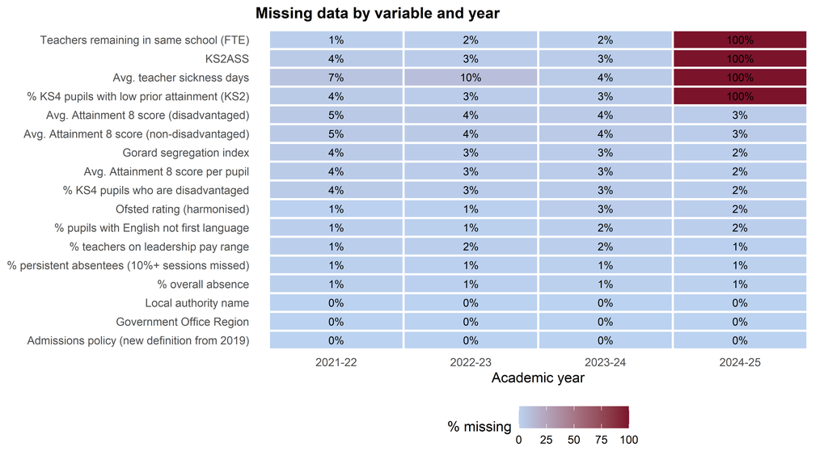

Figure 12: Missing data pattern across model variables by academic year

```r
miss_long <- model_panel %>%
  select(year_label, all_of(all_model_vars)) %>%
  group_by(year_label) %>%
  summarise(
    across(everything(), ~ sum(is.na(.)) / n() * 100),
    .groups = "drop"
  ) %>%
  pivot_longer(-year_label, names_to = "variable", values_to = "pct_missing") %>%
  mutate(variable = var_label(variable))

p_miss <- ggplot(miss_long, aes(x = year_label,
                                 y = fct_reorder(variable, pct_missing, .fun = max),
                                 fill = pct_missing)) +
  geom_tile(colour = "white", linewidth = 0.8) +
  geom_text(aes(label = sprintf("%.0f%%", pct_missing)), size = 3) +
  scale_fill_gradient(low = "#bbd2f0", high = "#7b132b",
                      name = "% missing", limits = c(0, 100)) +
  labs(x = "Academic year", y = NULL,
       title = "Missing data by variable and year") +
  theme_pub +
  theme(panel.grid = element_blank())

save_fig(p_miss, "missing_heatmap", width = 8, height = 5)
p_miss
```

The heatmap makes the pattern stark: missingness is concentrated almost entirely in the workforce and prior attainment variables for the 2024–25 year. For the earlier three years, data completeness is consistently high across all variables. This structured, year-specific pattern supports the use of a carry-forward imputation strategy rather than more complex multiple imputation approaches.

# 11 Imputation: 2024–25 Carry-Forward

Five predictor variables are unavailable for the 2024–25 academic year:

- **KS2ASS** — the cohort mean KS2 scaled score, which is the prior-attainment control used in the models (entered centred at 100 as `ks2_c`). No prior-attainment measure exists at all for this year: the KS2 assessments of 2019–20 and 2020–21 were cancelled during the pandemic, so the cohort reaching the end of KS4 in 2024–25 has no KS2 results, and the DfE publishes neither prior-attainment measures nor Progress 8 for it
- **PTPRIORLO** — the share of pupils with low KS2 prior attainment, unavailable for the same reason. It is retained in the panel for the specification comparison reported in the model experiments, but is no longer the prior-attainment control
- **remained_in_the_same_school** — workforce turnover data not yet published
- **teachers_on_leadership_pay_range_percent** — workforce pay data not yet published
- **average_number_of_days_taken** — workforce sickness data not yet published

These are imputed using a two-step approach:

1. **Carry-forward**: use the school’s 2023–24 value
2. **Fallback**: if no 2023–24 value exists, use the school-level mean across all available years

A flag variable `has_imputed_predictors` is set to `TRUE` for any 2024–25 row that received at least one imputed value.

```r
impute_vars <- c("KS2ASS", "PTPRIORLO", "remained_in_the_same_school",
                 "teachers_on_leadership_pay_range_percent",
                 "average_number_of_days_taken")
impute_vars <- intersect(impute_vars, names(model_panel))

rows_2425 <- model_panel %>% filter(year_label == "2024-25")
n_2425 <- nrow(rows_2425)

imputation_summary <- map_dfr(impute_vars, function(v) {
  n_available <- sum(!is.na(rows_2425[[v]]))
  n_missing   <- n_2425 - n_available
  tibble(
    Variable          = var_label(v),
    `2024-25 rows`    = n_2425,
    `Non-missing`     = n_available,
    `Still missing`   = n_missing,
    `% imputed/available` = round(n_available / n_2425 * 100, 1)
  )
})

flagged <- sum(rows_2425$has_imputed_predictors, na.rm = TRUE)

imputation_summary %>%
  kable(align = "lrrrr") %>%
  kable_styling(bootstrap_options = c("striped", "hover", "condensed"),
                full_width = FALSE) %>%
  footnote(general = paste0(flagged, " of ", n_2425,
                            " 2024-25 rows flagged as having imputed predictors (",
                            round(flagged / n_2425 * 100, 1), "%).")) %>%
  save_tbl("imputation_summary")
```

Table 13: Imputation summary for 2024-25 rows

| Variable | 2024-25 rows | Non-missing | Still missing | % imputed/available |
| --- | --- | --- | --- | --- |
| KS2ASS | 3347 | 0 | 3347 | 0 |
| % KS4 pupils with low prior attainment (KS2) | 3347 | 0 | 3347 | 0 |
| Teachers remaining in same school (FTE) | 3347 | 0 | 3347 | 0 |
| % teachers on leadership pay range | 3347 | 3314 | 33 | 99 |
| Avg. teacher sickness days | 3347 | 0 | 3347 | 0 |

Note:  
3224 of 3347 2024-25 rows flagged as having imputed predictors (96.3%).

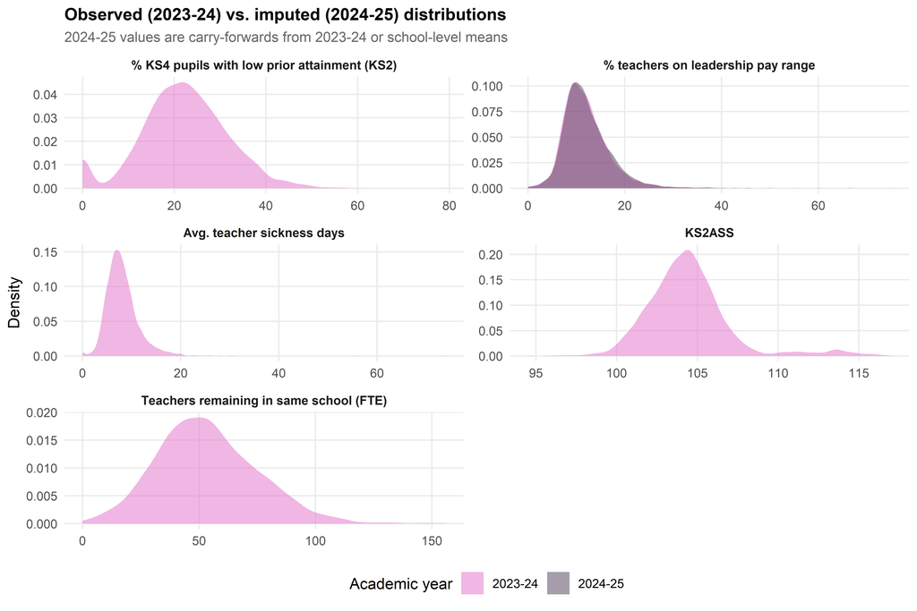

Figure 13: Comparison of observed (2023-24) vs. carried-forward (2024-25) values for imputed variables

```r
if (length(impute_vars) > 0) {
  compare_df <- model_panel %>%
    filter(year_label %in% c("2023-24", "2024-25")) %>%
    select(year_label, all_of(impute_vars)) %>%
    pivot_longer(-year_label, names_to = "variable", values_to = "value") %>%
    filter(!is.na(value)) %>%
    mutate(variable = var_label(variable))

  p_impute <- ggplot(compare_df, aes(x = value, fill = year_label)) +
    geom_density(alpha = 0.5, colour = NA) +
    facet_wrap(~ variable, scales = "free", ncol = 2) +
    scale_fill_manual(
      values = c("2023-24" = "#e16fca", "2024-25" = "#4e3c56"),
      name = "Academic year"
    ) +
    labs(x = NULL, y = "Density",
         title = "Observed (2023-24) vs. imputed (2024-25) distributions",
         subtitle = "2024-25 values are carry-forwards from 2023-24 or school-level means") +
    theme_pub

  save_fig(p_impute, "imputed_vs_observed", width = 8, height = 6)
  p_impute
}
```

## 11.1 Year-on-Year Stability of KS2 Prior Attainment

A key question for the carry-forward strategy is whether imputed variables are sufficiently stable from one year to the next at the school level. Figure 14 addresses this for KS2ASS (the cohort mean KS2 scaled score, the prior-attainment control used in the models) by plotting each school’s value in one year against its value in the next. If the variable were perfectly stable, all points would fall on the 45-degree line.

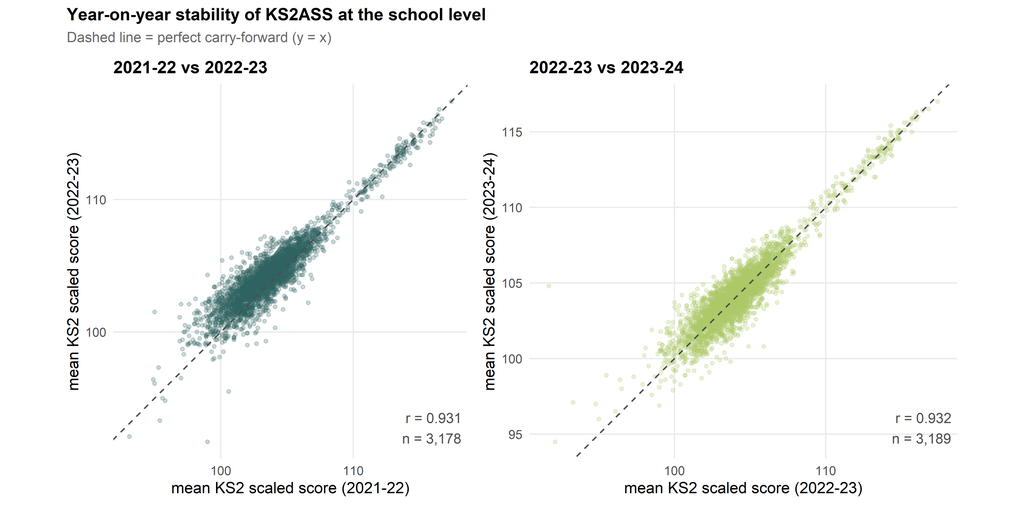

Figure 14: Year-on-year stability of KS2 prior attainment (mean scaled score) at the school level

```r
# Build wide data: one row per school with each year's KS2ASS
prior_wide <- model_panel %>%
  filter(!is.na(KS2ASS)) %>%
  select(URN, year_label, KS2ASS) %>%
  pivot_wider(names_from = year_label, values_from = KS2ASS,
              names_prefix = "y_")

# Pair 1: 2021-22 vs 2022-23
pair1 <- prior_wide %>%
  filter(!is.na(`y_2021-22`), !is.na(`y_2022-23`))
r1 <- cor(pair1$`y_2021-22`, pair1$`y_2022-23`)

# Pair 2: 2022-23 vs 2023-24
pair2 <- prior_wide %>%
  filter(!is.na(`y_2022-23`), !is.na(`y_2023-24`))
r2 <- cor(pair2$`y_2022-23`, pair2$`y_2023-24`)

p_scatter1 <- ggplot(pair1, aes(x = `y_2021-22`, y = `y_2022-23`)) +
  geom_point(alpha = 0.25, size = 1, colour = "#2e6260") +
  geom_abline(slope = 1, intercept = 0, linetype = "dashed", colour = "grey30") +
  annotate("text", x = Inf, y = -Inf,
           label = paste0("r = ", sprintf("%.3f", r1), "\nn = ", format(nrow(pair1), big.mark = ",")),
           hjust = 1.1, vjust = -0.5, size = 3.5, colour = "grey30") +
  labs(x = "mean KS2 scaled score (2021-22)",
       y = "mean KS2 scaled score (2022-23)",
       title = "2021-22 vs 2022-23") +
  coord_equal() +
  theme_pub

p_scatter2 <- ggplot(pair2, aes(x = `y_2022-23`, y = `y_2023-24`)) +
  geom_point(alpha = 0.25, size = 1, colour = "#abc766") +
  geom_abline(slope = 1, intercept = 0, linetype = "dashed", colour = "grey30") +
  annotate("text", x = Inf, y = -Inf,
           label = paste0("r = ", sprintf("%.3f", r2), "\nn = ", format(nrow(pair2), big.mark = ",")),
           hjust = 1.1, vjust = -0.5, size = 3.5, colour = "grey30") +
  labs(x = "mean KS2 scaled score (2022-23)",
       y = "mean KS2 scaled score (2023-24)",
       title = "2022-23 vs 2023-24") +
  coord_equal() +
  theme_pub

p_prior_scatter <- p_scatter1 + p_scatter2 +
  plot_annotation(
    title = "Year-on-year stability of KS2ASS at the school level",
    subtitle = "Dashed line = perfect carry-forward (y = x)",
    theme = theme(plot.title = element_text(face = "bold", size = 12),
                  plot.subtitle = element_text(colour = "grey40", size = 10))
  )

save_fig(p_prior_scatter, "ks2ass_year_scatter", width = 10, height = 5)
p_prior_scatter
```

Both panels show a tight clustering of schools along the 45-degree line, with high year-on-year correlations. This confirms that a school’s mean KS2 intake score is a stable, slow-moving characteristic. The degree of scatter is modest and symmetric around the diagonal, indicating no systematic drift. This pattern provides strong support for the carry-forward imputation of KS2ASS into 2024–25: if a school’s value barely changes from 2021–22 to 2022–23 or from 2022–23 to 2023–24, it is reasonable to assume a similar level of stability into the following year.

# 12 Derived Variables

## 12.1 Gorard Segregation Index

The Gorard segregation index measures how unevenly disadvantaged pupils are distributed across schools within each Local Authority ([calculation details](https://sru.soc.surrey.ac.uk/SRU30.html)). It is computed per LA per year as:

$$G_s = \frac{1}{2} \sum_{i=1}^{n} \left| \frac{F_i}{F_{\text{total}}} - \frac{T_i}{T_{\text{total}}} \right|$$

where $F_i$ is the number of disadvantaged pupils in school $i$, $F_{\text{total}}$ the LA total, and $T_i$, $T_{\text{total}}$ the corresponding all-pupil totals.

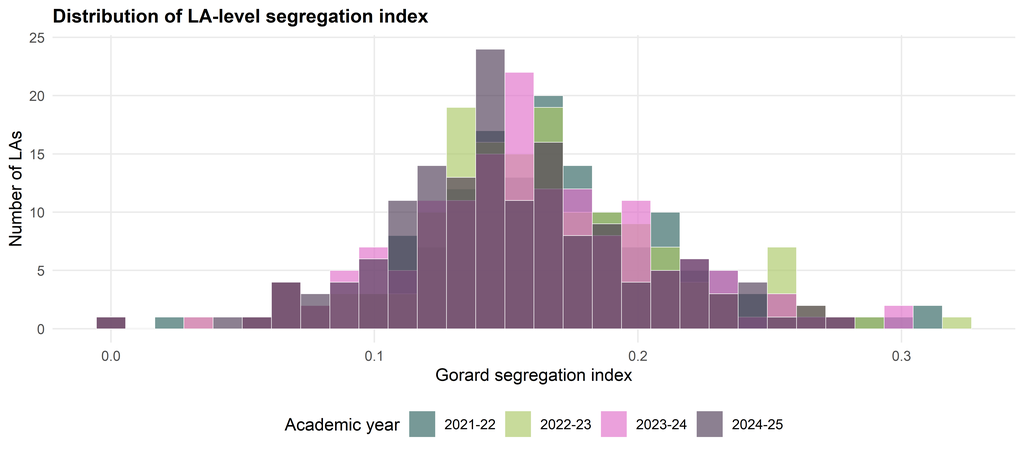

Figure 15: Distribution of Gorard segregation index across LAs by year

```r
gorard_la <- model_panel %>%
  filter(!is.na(gorard_segregation)) %>%
  distinct(LANAME, year_label, gorard_segregation)

p_gorard <- ggplot(gorard_la, aes(x = gorard_segregation, fill = year_label)) +
  geom_histogram(bins = 30, alpha = 0.65, position = "identity", colour = "white",
                 linewidth = 0.2) +
  scale_fill_manual(values = year_cols, name = "Academic year") +
  labs(x = "Gorard segregation index", y = "Number of LAs",
       title = "Distribution of LA-level segregation index") +
  theme_pub

save_fig(p_gorard, "gorard_segregation", width = 7, height = 4)
p_gorard
```

# 13 Correlation Structure

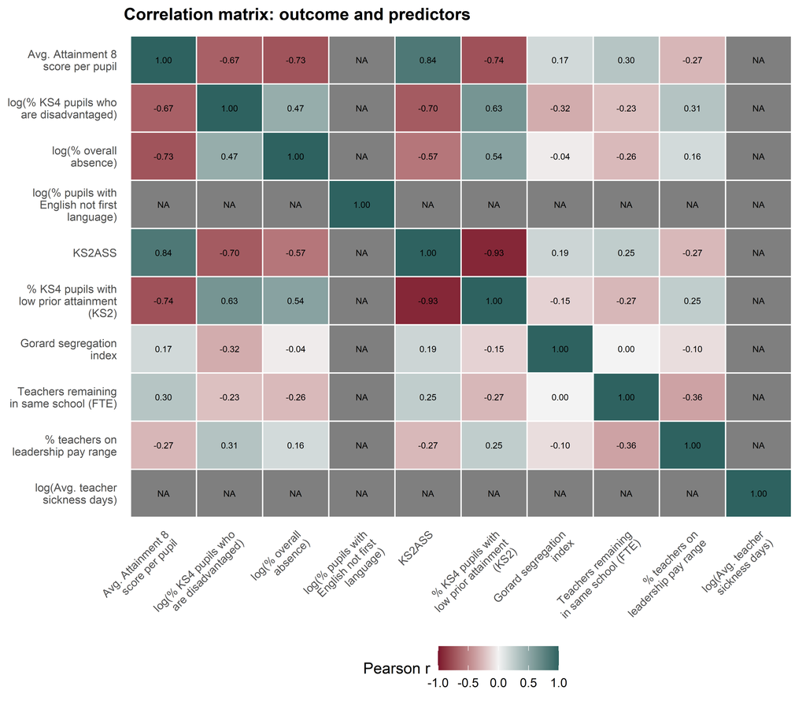

Figure 16: Pairwise Pearson correlations among the outcome and all fixed-effect predictors (log-transformed variables shown on the model scale)

```r
# Variables that enter the model as log(x)
log_transform_vars <- c("PTFSM6CLA1A", "PERCTOT", "PNUMEAL",
                         "average_number_of_days_taken")

cor_vars <- c("ATT8SCR", "PTFSM6CLA1A", "PERCTOT", "PNUMEAL",
              "KS2ASS", "PTPRIORLO", "gorard_segregation",
              "remained_in_the_same_school",
              "teachers_on_leadership_pay_range_percent",
              "average_number_of_days_taken")
cor_vars <- intersect(cor_vars, names(model_panel))

cor_data <- model_panel %>%
  select(all_of(cor_vars)) %>%
  drop_na() %>%
  mutate(across(all_of(intersect(log_transform_vars, names(.))), safe_log))

cor_mat <- cor(cor_data)

# Apply labels — prefix logged variables with "log()"
cor_labels <- sapply(cor_vars, function(v) {
  lbl <- var_label(v)
  if (v %in% log_transform_vars) paste0("log(", lbl, ")") else lbl
})
labs_vec <- str_wrap(cor_labels, width = 20)
rownames(cor_mat) <- labs_vec
colnames(cor_mat) <- labs_vec

cor_long <- cor_mat %>%
  as.data.frame() %>%
  rownames_to_column("var1") %>%
  pivot_longer(-var1, names_to = "var2", values_to = "r") %>%
  mutate(
    var1 = factor(var1, levels = rev(labs_vec)),
    var2 = factor(var2, levels = labs_vec)
  )

p_cor <- ggplot(cor_long, aes(x = var2, y = var1, fill = r)) +
  geom_tile(colour = "white", linewidth = 0.5) +
  geom_text(aes(label = sprintf("%.2f", r)), size = 2.2) +
  scale_fill_gradient2(low = "#7b132b", mid = "#f3f3f3", high = "#2e6260",
                       midpoint = 0, limits = c(-1, 1), name = "Pearson r") +
  labs(x = NULL, y = NULL,
       title = "Correlation matrix: outcome and predictors") +
  theme_pub +
  theme(
    axis.text.x = element_text(angle = 45, hjust = 1, size = 8),
    axis.text.y = element_text(size = 8),
    panel.grid = element_blank()
  )

save_fig(p_cor, "correlation_matrix", width = 9, height = 7)
p_cor
```

# 14 Summary

The full panel dataset contains **17,130** school-year observations from **4534** unique schools. After restricting to mainstream state-funded schools (Academies and Maintained schools), the **analysis sample** comprises **13,419** school-year observations from **3523** schools across **152** Local Authorities and **4 academic years** (2021–22 to 2024–25). Key features:

· School Attainment Tool